# Part-5

Aylin Kallmayer

7/8/2020

Now that you have the summary data frame for the search experiment, we will want to add the behavioral data to that data frame. This will allow us to conduct the analysis we need.

Now we will import the behavioral data (the .csv files in our exampleDataSearchExperiment-master folder). We can select the variables we want

```r
raw.data.path <- paste(getwd(),"/part2/exampleDataSearchExperiment-master/", sep = "")
# behav_dat<-EyEduImportBehavioralData(raw.data.path,
#                                     selection = c("subject_nr", "count_trial_sequence",
#                                                    "correct",
#                                                    "response_time",
#                                                    "gaze_response",
#                                                    "stimulus",
#                                                    "condition"))
files <- list.files(raw.data.path , pattern = "csv", recursive = F)

behav_dat <- NULL
for(file in files){
  print(paste(raw.data.path, file, sep = ""))
  temp <- read.csv(paste(raw.data.path, file, sep = ""),sep = ",", header = T, stringsAsFactors = F)
  behav_dat <- rbind(behav_dat,temp)
}
```

```
[1] "/home/aylin/Aylin_Git/PsyMsc_4_time_series_analysis_sandbox/part2/exampleDataSearchExperiment-master/Danvers.csv"
[1] "/home/aylin/Aylin_Git/PsyMsc_4_time_series_analysis_sandbox/part2/exampleDataSearchExperiment-master/Jones.csv"
[1] "/home/aylin/Aylin_Git/PsyMsc_4_time_series_analysis_sandbox/part2/exampleDataSearchExperiment-master/Maximov.csv"
[1] "/home/aylin/Aylin_Git/PsyMsc_4_time_series_analysis_sandbox/part2/exampleDataSearchExperiment-master/Parker.csv"
[1] "/home/aylin/Aylin_Git/PsyMsc_4_time_series_analysis_sandbox/part2/exampleDataSearchExperiment-master/Prince.csv"
[1] "/home/aylin/Aylin_Git/PsyMsc_4_time_series_analysis_sandbox/part2/exampleDataSearchExperiment-master/Raven.csv"
```

```r
behav_dat <- select(behav_dat, subject_nr, count_trial_sequence, correct, response_time, gaze_response, stimulus, condition)
```

### Behavioral analysis

1. Get a “sense” of your data frame
2. access individial variables
3. choose only a subsection of your data

Let’s start with just the behavioral data. This is currently stored in a data frame called behav_dat

```r
load("./part2/exampleDataSearchExperiment-master/fixation_summary.Rda")
str(behav_dat)
```

```
'data.frame':   60 obs. of  7 variables:
 $ subject_nr          : int  3 3 3 3 3 3 3 3 3 3 ...
 $ count_trial_sequence: int  0 1 2 3 4 5 6 7 8 9 ...
 $ correct             : chr  "undefined" "1" "1" "0" ...
 $ response_time       : int  3760 1073 1063 1310 1729 1056 1894 1161 1389 3975 ...
 $ gaze_response       : chr  NA "correct" "correct" "incorrect" ...
 $ stimulus            : chr  "C_4INCON" "C_120CON" "C_12INCON" "C_68CON" ...
 $ condition           : chr  "INCON" "CON" "INCON" "CON" ...
```

```r
summary(behav_dat)
```

```
   subject_nr  count_trial_sequence   correct          response_time  gaze_response        stimulus          condition
 Min.   :1.0   Min.   :0.0          Length:60          Min.   : 709   Length:60          Length:60          Length:60
 1st Qu.:2.0   1st Qu.:2.0          Class :character   1st Qu.:1126   Class :character   Class :character   Class :character
 Median :3.5   Median :4.5          Mode  :character   Median :1380   Mode  :character   Mode  :character   Mode  :character
 Mean   :3.5   Mean   :4.5                             Mean   :1838
 3rd Qu.:5.0   3rd Qu.:7.0                             3rd Qu.:1899
 Max.   :6.0   Max.   :9.0                             Max.   :5000
```

```r
summary(fixation.summary)
```

```
   fix.start           fix.end          fix.duration     fix.pos.x        fix.pos.y     fixation.index    trial.index
 Min.   :16830872   Min.   :16831171   Min.   : 99.0   Min.   : 372.7   Min.   :120.8   Min.   : 1.000   Min.   : 1.000
 1st Qu.:18154478   1st Qu.:18154661   1st Qu.:117.0   1st Qu.: 680.3   1st Qu.:405.5   1st Qu.: 2.000   1st Qu.: 2.000
 Median :18751291   Median :18751516   Median :167.0   Median : 836.5   Median :489.9   Median : 4.000   Median : 5.000
 Mean   :20220819   Mean   :20221005   Mean   :185.9   Mean   : 824.3   Mean   :464.4   Mean   : 5.421   Mean   : 5.225
 3rd Qu.:22512913   3rd Qu.:22513100   3rd Qu.:233.0   3rd Qu.: 975.0   3rd Qu.:579.5   3rd Qu.: 7.000   3rd Qu.: 8.000
 Max.   :26063168   Max.   :26063385   Max.   :516.0   Max.   :1303.7   Max.   :833.9   Max.   :20.000   Max.   :10.000

 stimulus.id          aoi.index   aoi.line.index  aoi.label         participant.name   participant.nr
 Length:432         Min.   :1     Mode:logical   Length:432         Length:432         Min.   :1.000
 Class :character   1st Qu.:1     NA's:432       Class :character   Class :character   1st Qu.:2.000
 Mode  :character   Median :1                    Mode  :character   Mode  :character   Median :3.000
                    Mean   :1                                                          Mean   :3.262
                    3rd Qu.:1                                                          3rd Qu.:5.000
                    Max.   :1                                                          Max.   :6.000
                    NA's   :322
```

```r
str(fixation.summary)
```

```
'data.frame':   432 obs. of  13 variables:
 $ fix.start       : num  18703167 18703566 18703816 18704099 18704448 ...
 $ fix.end         : num  18703449 18703783 18703999 18704232 18704648 ...
 $ fix.duration    : num  282 217 183 133 200 117 100 250 150 200 ...
 $ fix.pos.x       : num  832 749 602 551 911 ...
 $ fix.pos.y       : num  188 376 573 590 635 ...
 $ fixation.index  : int  1 2 3 4 5 6 7 8 9 10 ...
 $ trial.index     : int  1 1 1 1 1 1 1 1 1 1 ...
 $ stimulus.id     : chr  "18" "18" "18" "18" ...
 $ aoi.index       : int  NA NA NA NA NA NA NA NA NA NA ...
 $ aoi.line.index  : logi  NA NA NA NA NA NA ...
 $ aoi.label       : chr  NA NA NA NA ...
 $ participant.name: chr  "Danvers" "Danvers" "Danvers" "Danvers" ...
 $ participant.nr  : num  3 3 3 3 3 3 3 3 3 3 ...
```

```r
# convert the "correct" variable to numeric
behav_dat$correct <- as.numeric(behav_dat$correct)
```

```
NAs introduced by coercion
```

Get the mean response_time for each condition:

```r
(agg <- aggregate(response_time ~ condition, mean, data=behav_dat))
```

| condition | response_time |
| --- | --- |
| CON | 1461.167 |
| INCON | 2215.000 |

Plot the RTs split by condition:

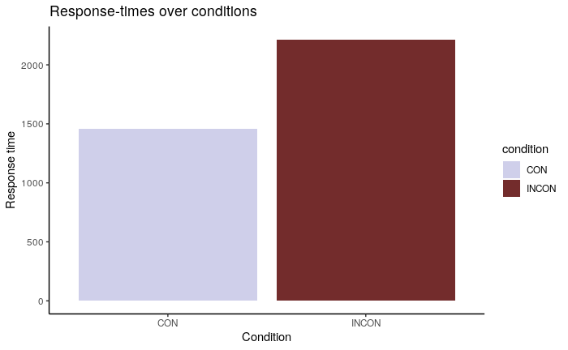

```r
ggplot(agg, aes(x=condition, y=response_time, fill=condition))+
  geom_bar(stat="identity")+
  labs(x="Condition", y="Response time", title="Response-times over conditions")+
  scale_fill_manual(values=c("#cfcfea", "#732c2c"))+
  theme_classic()
```

Merge the behavioral data with the fixation data and clean:

```r
clean_data <- fixation.summary %>%
  dplyr::rename(subject_nr = participant.nr,
         count_trial_sequence = trial.index) %>%
  full_join(behav_dat) %>%
  filter(response_time > 100 & response_time < 5000, # clean data - take out rows where RTs were lower than 100 and more than 5000
         correct == 1 & !is.na(correct) & !is.na(aoi.label)) # also take only the correct trials
```

### Plot fixations

We are again using ggplot, but this time we are using something called geom_point, seperated by condition:

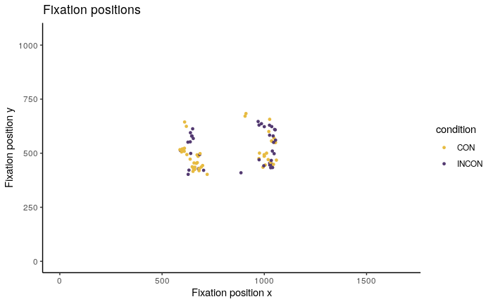

```r
ggplot(clean_data, aes(x=fix.pos.x, y=fix.pos.y, color=condition))+
  geom_point(size=1)+
  coord_cartesian(xlim=c(0, width), ylim=c(0,height))+
  scale_y_reverse()+
  labs(x="Fixation position x", y="Fixation position y", title="Fixation positions")+
  scale_color_manual(values=c("#e7bb41", "#533a71"))+
  theme_classic()
```

Take duration into account as a weight for the circle size/colour/etc. Make sure the constant you pick works with your fixation duration values try adjusting the constant and see what happens to your plot.

```r
(clean_data$weight <- clean_data$fix.duration/10)
```

```
 [1] 15.0 15.0 30.0 15.0  9.9 35.0 10.0 10.0 25.0 10.0 13.4 46.6 20.0 28.3  9.9 31.7 10.0 15.0 30.0 48.3 15.0 21.6 15.0 10.0 18.3 13.3 10.1
[28] 10.1 10.0 10.0 28.3 10.0 15.0 11.7 10.0 13.3 10.0 20.0 10.0 11.7 16.6 13.4 11.6 23.3 15.0 23.4 13.3 10.0 10.1 10.0 11.6  9.9 39.9 10.0
[55] 10.0 13.3 10.0 13.4  9.9 10.1 11.6 18.3 21.6 10.0 16.7 15.0 20.0 10.0 11.7 26.7 21.6 25.0 10.0 25.0 23.3 13.3 10.0  9.9 20.0 23.3  9.9
[82] 18.3 10.0 10.0 14.9  9.9  9.9
```

```r
(clean_data$size <- clean_data$fix.duration/100)
```

```
 [1] 1.50 1.50 3.00 1.50 0.99 3.50 1.00 1.00 2.50 1.00 1.34 4.66 2.00 2.83 0.99 3.17 1.00 1.50 3.00 4.83 1.50 2.16 1.50 1.00 1.83 1.33 1.01
[28] 1.01 1.00 1.00 2.83 1.00 1.50 1.17 1.00 1.33 1.00 2.00 1.00 1.17 1.66 1.34 1.16 2.33 1.50 2.34 1.33 1.00 1.01 1.00 1.16 0.99 3.99 1.00
[55] 1.00 1.33 1.00 1.34 0.99 1.01 1.16 1.83 2.16 1.00 1.67 1.50 2.00 1.00 1.17 2.67 2.16 2.50 1.00 2.50 2.33 1.33 1.00 0.99 2.00 2.33 0.99
[82] 1.83 1.00 1.00 1.49 0.99 0.99
```

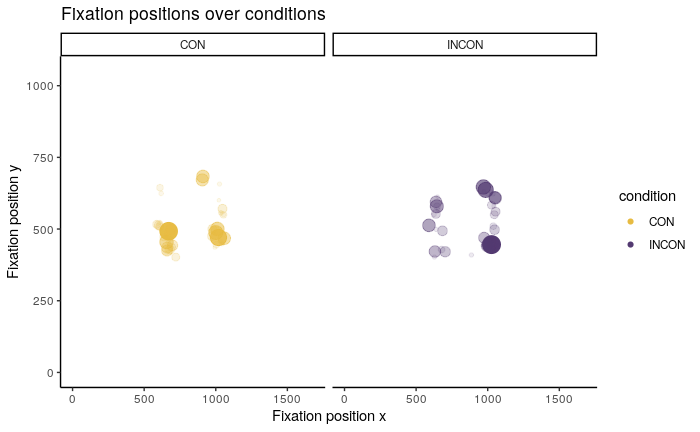

```r
ggplot(clean_data, aes(x=fix.pos.x, y=fix.pos.y, color=condition))+
  geom_point(aes(alpha=weight, size=size))+
  facet_grid(~condition)+
  coord_cartesian(xlim=c(0, width), ylim=c(0,height))+
  scale_y_reverse()+
  guides(alpha=F, size=F)+
  labs(x="Fixation position x",y="Fixation position y", title="Fixation positions over conditions")+
  scale_color_manual(values=c("#e7bb41", "#533a71"))+
  theme_classic()
```

OK, this was fun, but now we should actually try to see if participants looked longer at the inconsistent objects. We already know that they were slower, remember?… In our data frame we actually have marked the fixation which belong to the Interest Area of the object. Now you can aggregate these fixations and check if the dwell time in the interest area differes between condition, so we could check if the Decision time was affected - a sub-part of the RTs.

```r
agg_dwell <- aggregate(fix.duration ~ subject_nr+count_trial_sequence+condition+aoi.label, sum, data=clean_data)
(agg <- aggregate(fix.duration ~ condition + subject_nr, mean, data=agg_dwell))
```

| condition | subject_nr | fix.duration |
| --- | --- | --- |
| CON | 1 | 499.0000 |
| INCON | 1 | 333.0000 |
| CON | 2 | 350.0000 |
| INCON | 2 | 533.0000 |
| CON | 3 | 677.0000 |
| INCON | 3 | 439.0000 |
| CON | 4 | 342.0000 |
| INCON | 4 | 549.6667 |
| CON | 5 | 182.5000 |
| INCON | 5 | 315.5000 |

[output cut: 2 more lines]

Now plotting the results:

```r
table <- summarySEwithin(withinvars = "condition", idvar = "subject_nr", measurevar = "fix.duration"
                         , data = agg)
```

```
Automatically converting the following non-factors to factors: condition
```

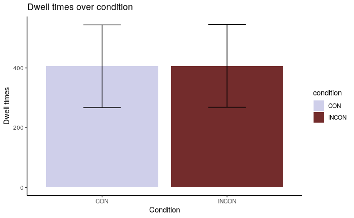

```r
ggplot(table, aes(x=condition, y=fix.duration, fill=condition))+
  geom_bar(stat="identity")+
  geom_errorbar(aes(ymin=fix.duration-sd, ymax=fix.duration+sd), width=.3)+
  labs(y="Dwell times", x="Condition", title="Dwell times over condition")+
  scale_fill_manual(values=c("#cfcfea", "#732c2c"))+
  theme_classic()
```